# Data Analysis and Communication of Results

With the clean data saved in a CSV file from the previous process a few insights were analysed and final findings communicated using statistical reports and visual plots. The following insights were sought from the dataset:

1. Comparison of retweet and favorite counts. To look at the relation beween the retweet and favorite counts, the two variables were plotted in a regression plot using the seaborn library's function regplot(). From the plot it was discovered that the two variables have a positive correlation.

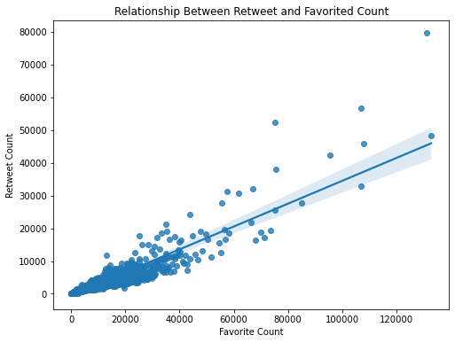

2. Dog breed distribution To answer the question which dog breeds are popular. The value_counts() function was used to count the number of tweets per each breed. Since there were many breeds we limited ourselves to the top ten breeds. This findings were then plotted in a bargraph.

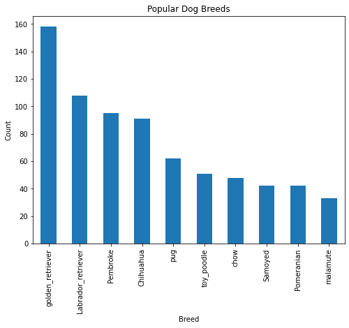

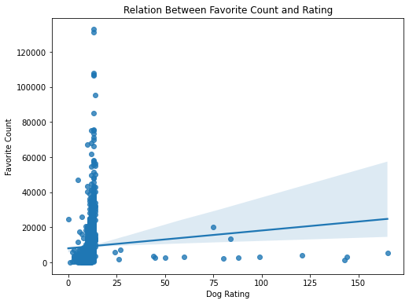